# Práctica en análisis de datos metagonómicos mediante herramientas bioinformaticas

J. David Rueda Reyes, Biólogo M. Sc.

14 noviembre de 2023

[figure not shown]

[Invemar](http://www.invemar.org.co)

# Metagenómica de microorganismos marinos

## Introducción

La biodiversidad siempre ha sido una importante línea de investigación debido a su gran relevancia. En estos estudios lo primero en lo que se piensa es en el número de especies presentes y sus abundancias, siendo estos los aspectos más directos y sencillos para iniciar el procesos de comprensión de la diversidad; sin embargo, como nos daremos cuenta en este curso, cuando se habla de biodiversidad hay muchos aspectos o propiedades emergentes que pueden ser tratados. Dentro de las múltiples aproximaciones para su comprensión y entendimiento, nos centraremos en aquellas basadas en la información contenida en el ADN de las distintas especies presentes en la naturaleza.

En aquellos estudios en los que se identifican los microorganismos presentes en ambientes (p. ej. marinos, terrestres e incluso en microambientes como piel y materia fecal mediante secuenciación masiva de marcadores moleculares son conocidos como microbiomas. Dada la implementación de técnicas de secuenciación masiva podemos además de identificar especies, también, es posible conocer sus abundancias y analizar su biodiversidad. Incluso interrelacionar los datos con características del ambiente en el que fueron tomadas. Esto acelera nuestra comprensión y entendimiento de la riqueza biológica que poseemos, la cual, está en riesgo y es de suma importancia tener a disposición herramientas rápidas, económicas y precisas para aportar las bases científicas necesarias en la toma de decisiones de conservación.

## Objetivos

### General:

- Analizar datos metagenómicos mediante herramientas bioinformáticas.

### Específicos:

- Aprender el manejo básico de herramientas bioinformáticas para metagenómica de microorganismos.
- Identificar microorganismos marinos a partir de secuenciación del marcador molecular 16S.
- Caracterizar comunidades microbiomas de sedimentos marinos.

## Herramientas bioinformáticas

El desarrollo de las tecnologías genómicas han permitido analizar la diversidad biológica de una manera más completa, ampliando nuestro entendimiento sobre la relación y el efecto entre genes, especies, comunidades y ambiente. Estos avances han aumentado significativamente la cantidad de datos obtenidos, haciendo de su análisis algo complejo que, además, requiere de herramientas y técnicas especializadas capaces de procesar millones de datos. Es así como toman relevancia las herramientas computacionales, las cuales, mediante múltiples programas (software) permiten sacar provecho de toda la información generada.

La mayoría de estos programas son una serie de comandos que realizan por nosotros los cálculos y análisis necesarios. Para el estudio de secuencias, es necesario estar familiarizado con lenguajes de programación debido a que muchos de estos están desarrollados en dichos lenguajes y para ser ejecutadas se deben utilizar las líneas de comando pertinentes. Conociendo el fundamento básico de la sintaxis del lenguaje que vamos a utilizar, nos facilitará el manejo de los datos y un mejor análisis de los mismos, por tanto, vamos a comenzar con familiarizarnos con el lenguaje de programación **R** mediante la interfaz gráfica Rstudio.

### R y Rstudio

**R** es un entorno de programación para diversos análisis estadísticos y representaciones gráficas. Es popular en la ciencia de datos debido a su versatilidad, pues con relativa facilidad se pueden integrar funciones y paquetes de otros lenguajes de programación, también es muy eficiente en el manejo de datos pesados, presenta un lenguaje (sintaxis) sencillo y genera gráficos de excelente calidad.

Lo primero que debemos realizar es descargar **R** ingresando al siguiente link, seleccionamos el sistema operativo de tu equipo y seguimos las instrucciones de instalación:

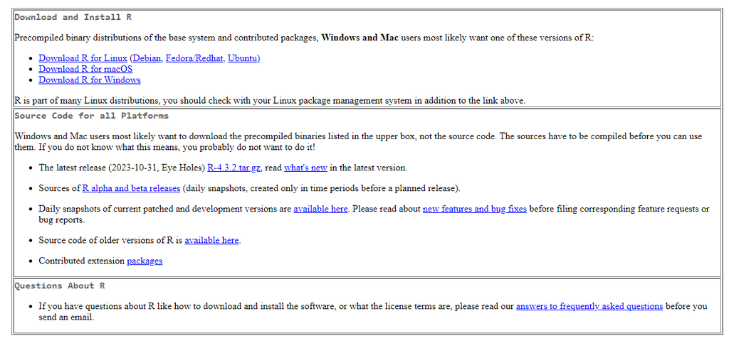

[Descargar r](https://cloud.r-project.org)

Para que la interacción con **R** sea mucho más completa y sencilla, también haremos uso de **Rstudio**, un ambiente integrado de desarrollo (IDE) para **R** y **phyton**. Vamos a descargarlo en su versión de Escritorio ingresando al siguiente link:

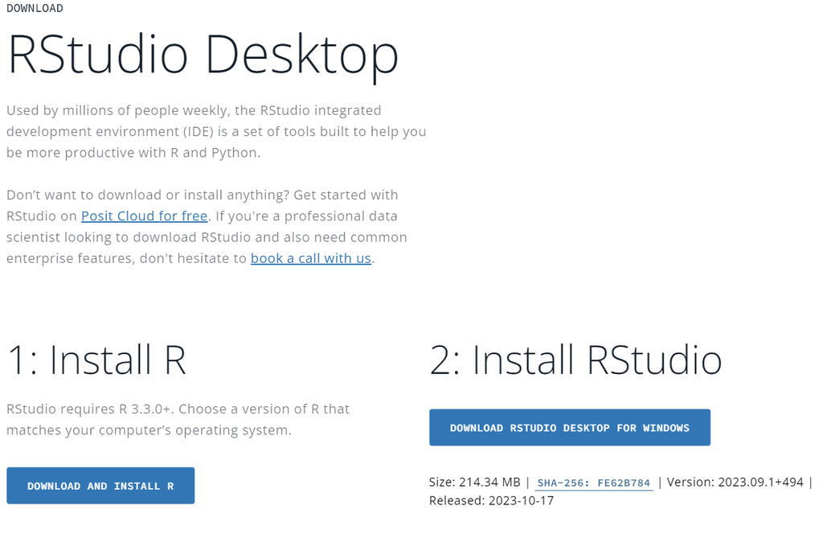

[Descargar Rstudio](https://posit.co/download/rstudio-desktop/)

La mejor manera de utilizar estás herramientas es mediante la construcción e implementación de tu código en archivo de texto conocido como *script*, en los cuales consignará todo tu código. También es importante tener presente los principales factores por los cuales vamos a utilizar **R**:

- Comprensión y dominio las acciones que ejecutas en tu análisis
- Rápida **reproducibilidad**
- Edición, corrección y ajuste de tu *script*
- Agregar comentarios y observaciones de tus análisis en el *script*
- Gran variedad de gráficos de alta calidad.

Al abrir **Rstudio** nos encontraremos con 4 secciones, cada una con funciones específicas:

- Superior-izquierda: Editor de texto
- Superior-derecha: Ambiente e historial de trabajo
- Inferior-izquierda: Consola de **R**
- Inferior-derecha: Archivos, gráficos, paquetes y ayuda

[figure not shown]

Los estudios metagenómicos son relativamente recientes, con lo cual, constantemente diseñan nuevos paquetes para complementar y actualizar los análisis. Esto hace que debamos recurrir a muchos complementos para poder llevar a cabo un correcto estudio de datos metagenómicos. Muchos de los complementos están en desarrollo, por tanto, para los usuarios windows es recomendable también instalar **Rtools**

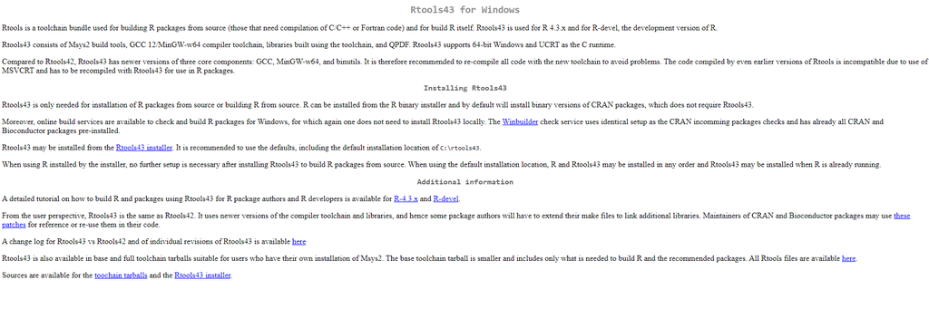

[Descargar Rtool](https://cran.r-project.org/bin/windows/Rtools/rtools43/rtools.html)

Ya identificadas las partes del programa, podemos empezar. En el editor de texto vamos a abrir un nuevo *script* oprimiendo Ctrl + Shift + N, e inmediatamente se abrirá en una pestaña un documento en blanco donde escribiremos todas nuestras líneas de comandos. Como se había mencionado, es posible agregar comentarios en el *script* simplemente anteponiendo `#´, sin embargo, lo más importante son los comandos o códigos que realizan una función concreta. Estos están compuestos por 2 partes, 1) el nombre del código y 2) sus parámetros.

Veamos un ejemplo:

```r
# Esto es un comentario
install.packages("devtools") # Esto es un comando

# cargar paquete a nuestro entorno de trabajo
library("devtools")
```

Acá nos encontramos con el comando **install.packages()** para instalar un paquete, en este caso es **devtools**. Posteriormente y para acceder a las funciones debemos cargar a nuestro entorno de trabajo el paquete que vamos a utilizar.